# The dependency of learning rates on exchange rate fluctuations and a method to correct them

Sourcefile and calculations

# Results for PV – in lead currency USD & with BNEF marketshare

## Parameters

We chose 6 relevant currencies (CNY, EUR, GBP, INR, JPY, USD) and calculate a learning rate between 2006 and 2016. We look only at PV projects above 5 MW.

# Data

## Load and prepare BNEF data

Our analysis is based on the Bloomberg New Energy Finance (BNEF) renewable energy database. The dataset is copyright protected and can not be shared. We use the BNEF dataset because it gives investment costs for individual installations and projects in the original currencies, or allows for conversion to the domestic currency of each project.

As base unit, we use local value per capacity (e.g. USD/W)

We subset the data according to different criteria:

```r
commissioned_projects <- filter(data_projects,
    status == "Commissioned") %>%
  mutate(subset_name = "BNEF commissioned")

relevant_projects <- filter(commissioned_projects,
    capacity >= params$capacity_threshold,
    !is.na(date)) %>%
  mutate(subset_name = "BNEF relevant")

non_relevant_projects1 <- filter(commissioned_projects,
    capacity < params$capacity_threshold) %>%
  mutate(subset_name = "BNEF non-relevant")

non_relevant_projects2 <- filter(commissioned_projects,
    capacity >= params$capacity_threshold,
    is.na(date)) %>%
  mutate(subset_name = "BNEF non-relevant")
```

### Completion of dataset with currencies

We consistently use the short ISO currency codes. Hence we convert the long currency codes to short ones.

The BNEF dataset does not consistenly report the original, local currencies. In cases where the local currency is missing, we assumed that projects were financed in the main currency of the corresponding project countries. Our assumption is justified by an inital data exploration that shows that this correlation holds true for most projects that had the currency information in the first place.

| id | capacity | total_local_value | total_usd_value | local_currency_long | country | date | status | local_value | year | subset_name |
| --- | --- | --- | --- | --- | --- | --- | --- | --- | --- | --- |
| 28605 | 5.0 | 768.0 | NA | NA | India | 2011-11-21 | Commissioned | 153.60 | 2011 | BNEF relevant |
| 72760 | 7.5 | 15.3 | NA | NA | Romania | 2013-02-01 | Commissioned | 2.04 | 2013 | BNEF relevant |

### Outlier treatment

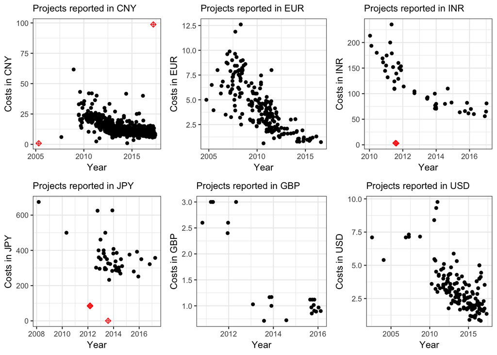

Overview of BNEF data and outliers.

From *projects_with_costs_with_outliers*, we exclude 9 projects as outliers because they have implausible costs that deviate very strongly (a factor 10 or more) from the overall trend and have most likely been entered incorrectly in the BNEF database. Compare the outliers.csv for details and see the plots bellow.

### Overview

```
##                            description projects project.share  capacity
## 1                                  all    22987            NA 516698.76
## 2                     all commissioned    14250     1.0000000 188910.95
## 3                         all relevant     7363     0.5167018 173188.44
## 4 all relevant with costs and outliers     2174     0.1525614  62230.49
## 5              all relevant with costs     2165     0.1519298  62100.29
## 6  all relevant with costs in interval     1991     0.1397193  56962.24
##   capacity.share
## 1             NA
## 2      1.0000000
## 3      0.9167729
## 4      0.3294171
## 5      0.3287278
## 6      0.3015296
```

The BNEF dataset contains a total of 22987 PV projects, of which 14250 are commissioned. Of those commissioned projects, we consider 7363 as relevant because they have a capacity of >= 5 MW, which is an indication that their local-cost component is low. Among the comissioned projects, some are not relevant (to caluclate learning rates) because they are either below that threshold (6670), above but miss a financing date record (210) or are reported in other, minor currencies.

Finally, only **2165 projects** have a financing costs in one of the relevant currencies. We use these projects , i.e. 32.9% of worldwide capacity to calculate the learning rates.These numbers and the corresponding capacity they represent are sumarised in the table below.

## Load and prepare IRENA data

If the parameter is set, we also use the IREAN dataset to calculate market shares. The IRENA data better represent the market shares than the BNEF data. For the calculations of the learning rates we need curreny information that the IRENA dataset does not include. Hence, we assume that projects in a country were financed in the main currencies. Compare Step 1 of Method 2 for the graph.

## Exchange rates

Exchange rates are from OFX and OECD, and the defaltors are based on OECD Consumer Price Index (CPI) data. We take the yearly average as basis for our calculations

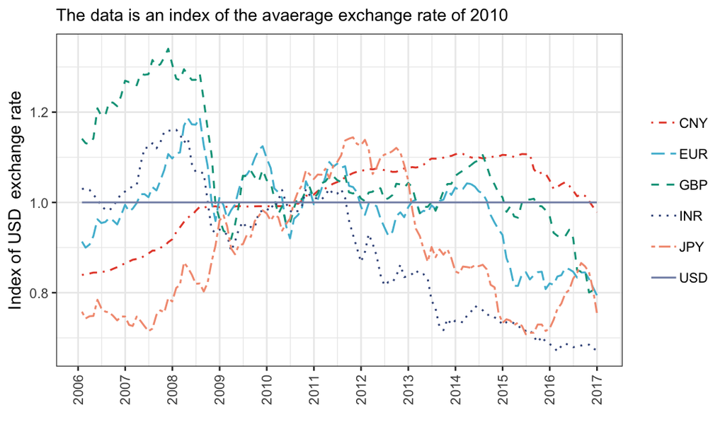

Comparison of all different exchange rates

## Deflators

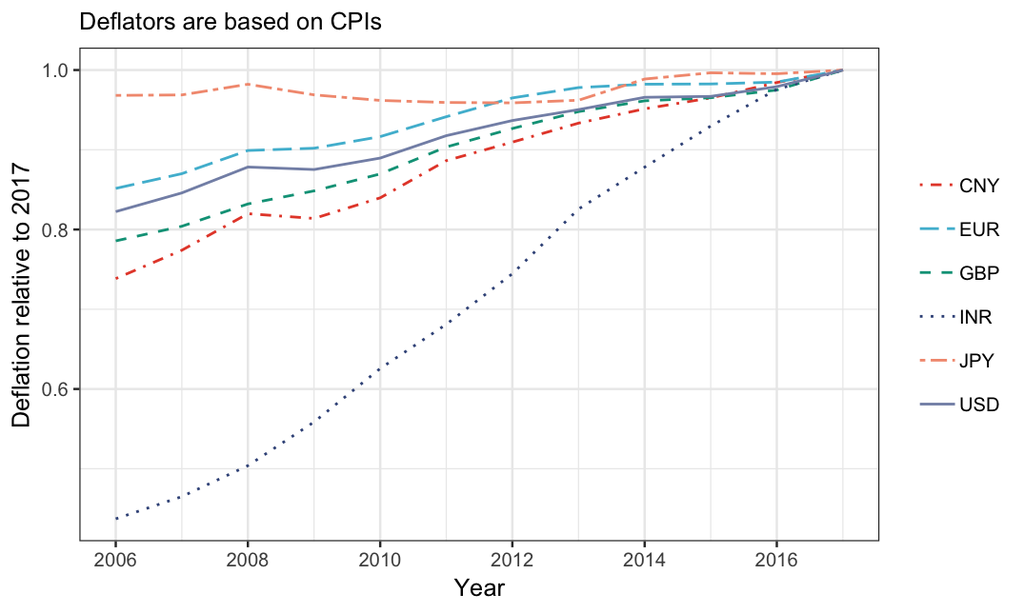

Deflation

## Cummulative sums

X is the global cumulative deployment in year t -> cummulative sum of x_global (sum of xj) per year

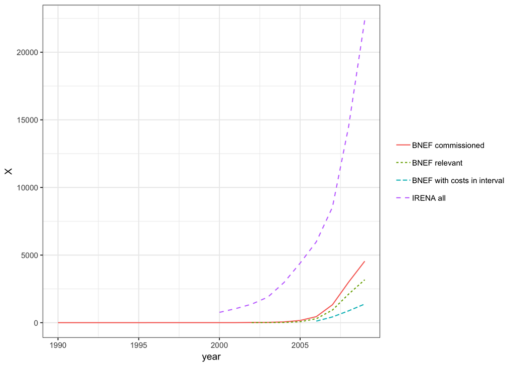

To get a good estimate of the learning rate, the underyling cummulative capacity should reflect the actual global deplyoment. If we took a subset, the learning rate would be overestimated. The plot indicates that there is a large difference in the global cummulative deplyoment in the subsets. So:

- if only working with the BNEF dataset, we take BNEF relevant, as they only consider 5MW projects. They fulfill our assumption that large projects are global.
- to improve results, we should take the IRENA data.

# Learning rate calculations

For a detailed explanation of the theories behind the learning rates calculations and currency corrections, compare our paper.

## Method 1: Calculation of the uncorrected learning rates

To calculate the simple learning rates, we convert **all available project costs** to different currencies. We then derive the learning rate for each currency from the global average costs $C_{global,t,2017}^{i}$ of all available projects.

In Table 1 & 2 and Figure 1, we present the results of the method 1 approach.

### Step 1: Calculation of costs in every relevant currency

In the first step, we calculate the value for each project in each relevant currency (CNY, EUR, GBP, INR, JPY, USD).

1. We add new variables for every relevant currency.
2. For each project, we calculate the value of the lead currency (USD) from the local value and an exchange rate that is either close to the project date or fixed for each year (if always_use_yearly_er == yes). To be consistent with method 2, we use a fixed exchange rate per year in our paper.
3. We caluculate the values in each relevant currency from the lead currency value and the exchange rates (see 2).

| id | date | capacity | local_currency | local_value | year | subset_name | CNY | EUR | GBP | INR | JPY | USD |
| --- | --- | --- | --- | --- | --- | --- | --- | --- | --- | --- | --- | --- |
| 120958 | 2016-07-09 | 40.00 | CNY | 8.3000000 | 2016 | BNEF with costs in interval | 8.300000 | 1.1295345 | 0.92151680 | 83.964785 | 135.58859 | 1.2496296 |
| 70992 | 2016-03-30 | 10.00 | CNY | 8.3000000 | 2016 | BNEF with costs in interval | 8.300000 | 1.1295345 | 0.92151680 | 83.964785 | 135.58859 | 1.2496296 |
| 54580 | 2012-06-20 | 20.00 | CNY | 13.2500000 | 2012 | BNEF with costs in interval | 13.250000 | 1.6321875 | 1.32440045 | 111.979331 | 167.39396 | 2.0990784 |
| 54582 | 2013-06-19 | 20.00 | CNY | 10.0000000 | 2013 | BNEF with costs in interval | 10.000000 | 1.2155424 | 1.03170097 | 94.181317 | 157.22447 | 1.6141450 |
| 128937 | 2016-10-26 | 20.00 | CNY | 8.0000000 | 2016 | BNEF with costs in interval | 8.000000 | 1.0887079 | 0.88820896 | 80.929913 | 130.68779 | 1.2044623 |
| 56830 | 2012-07-03 | 20.00 | CNY | 11.1700000 | 2012 | BNEF with costs in interval | 11.170000 | 1.3759648 | 1.11649457 | 94.400689 | 141.11626 | 1.7695627 |
| 71970 | 2013-10-09 | 30.00 | CNY | 10.0000000 | 2013 | BNEF with costs in interval | 10.000000 | 1.2155424 | 1.03170097 | 94.181317 | 157.22447 | 1.6141450 |
| 128179 | 2013-10-25 | 30.00 | CNY | 10.6926667 | 2013 | BNEF with costs in interval | 10.692667 | 1.2997390 | 1.10316346 | 100.704943 | 168.11488 | 1.7259515 |
| 102220 | 2014-10-28 | 20.00 | CNY | 8.5000000 | 2014 | BNEF with costs in interval | 8.500000 | 1.0411396 | 0.83972765 | 84.417635 | 146.02818 | 1.3836048 |
| 127003 | 2015-01-06 | 100.00 | CNY | 11.0000000 | 2015 | BNEF with costs in interval | 11.000000 | 1.5920990 | 1.15615448 | 113.292530 | 213.78795 | 1.7670465 |

[output cut: 1981 more lines]

### Step 2. Aggregate data to means

In the second step, we aggregate the data by yearly averages for each currency. The mean is a not weighted (in contrast to method 2) average of all projects.

```r
average_global_costs <- projects_with_costs_in_currencies %>%
  select(year, !!relevant_currencies) %>%
  gather("currency", "value", !!relevant_currencies) %>%
  group_by(currency, year) %>%
  summarise(nominal_costs = mean(value)) %>% ungroup()
```

### Step 3. Convert to real values (in 2017 units)

We convert this the average in national nominal currency to the real 2017 values for each base currency.

### Step 4. Calculation of learning rates

We calculate the learning rate in each interval and for each currency using a linear regression (see calculate_learning_rate()).

```
##  [1] 10.422597 10.935546 11.376620  5.830933  5.113605  3.853675  2.641035
##  [8]  2.162480  1.887182  1.631558  1.499018
```

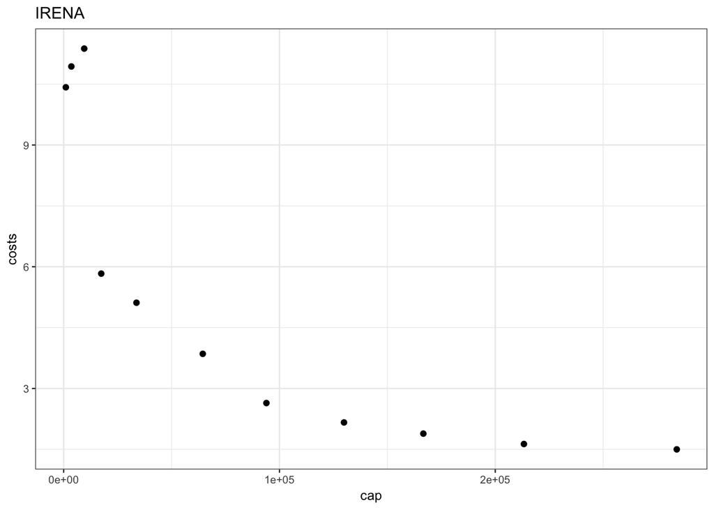

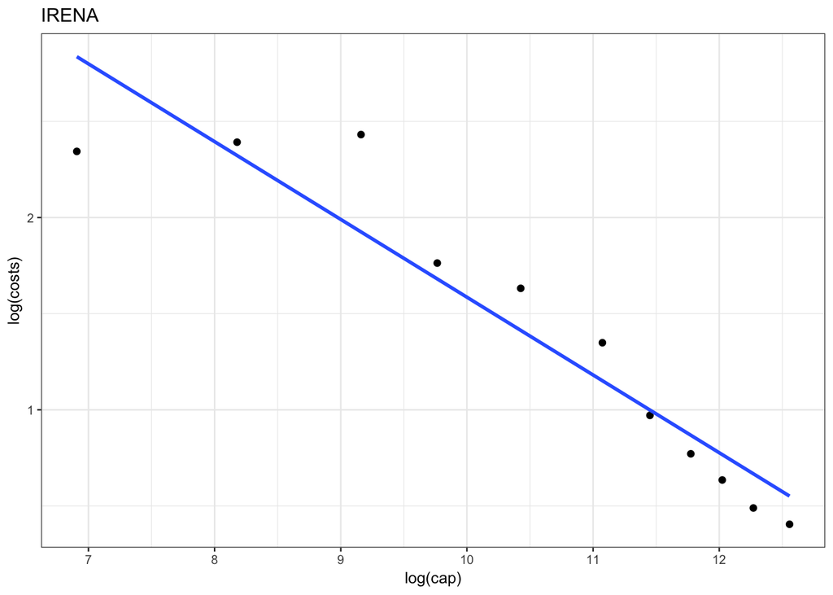

```
##
## Call:
## lm(formula = log(costs) ~ log(cumulative_capacity))
##
## Residuals:
##      Min       1Q   Median       3Q      Max
## -0.49265 -0.13936 -0.02787  0.13989  0.50622
##
## Coefficients:
##                          Estimate Std. Error t value Pr(>|t|)
## (Intercept)               5.63085    0.50751  11.095 1.50e-06 ***
## log(cumulative_capacity) -0.40451    0.04765  -8.489 1.37e-05 ***
## ---
## Signif. codes:  0 '***' 0.001 '**' 0.01 '*' 0.05 '.' 0.1 ' ' 1
##
## Residual standard error: 0.2745 on 9 degrees of freedom
## Multiple R-squared:  0.889,  Adjusted R-squared:  0.8766
## F-statistic: 72.06 on 1 and 9 DF,  p-value: 1.374e-05
```

### Results

```
##     2006-2011 2012-2016 2006-2016
## CNY 20.210000 30.050000 27.690000
## EUR 17.310000 20.360000 23.110000
## GBP 13.710000 24.480000 22.400000
## INR 20.270000 30.350000 26.640000
## JPY 20.420000 13.810000 24.050000
## USD 16.420000 30.390000 24.450000
## sd   2.729496  6.784408  2.049563
```

```
##     2006-2011 2012-2016 2006-2016
## CNY     81.60     94.66     91.78
## EUR     80.37     80.36     91.58
## GBP     70.69     83.57     87.02
## INR     79.65     98.20     91.97
## JPY     76.35     75.85     90.97
## USD     72.55     98.58     88.90
```

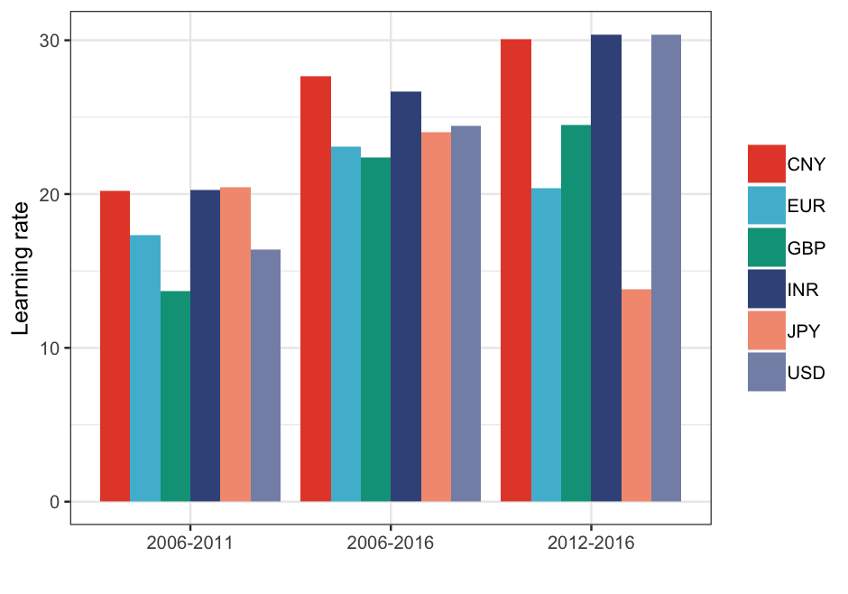

Simple learning rates in different intervals.

## Method 2: Currency-corrected learning rates

We calculate our improved currency-corrected learning rate in the lead currency **USD** The resulting, single learning rate is based on the *weighted average global cost converted to lead currency* $P_{t,2017}^l$.

### Step 1: Marketshare calculation

A notable difference to the uncorrected learning rate method, is that we weighting the average global costs by the marketshares $\delta$. For those, we have two datasource. (1) BNEF which is also used to calculate the learning rates and (2) IRENA. The IRENA data represents more capacity and is a better measure of the global market shares.

#### Marketshare plots (BNEF)

The market share of PV deplyoment in each currency and year is relevant. To calculate the market share of different currencies, we derive delta values from BNEF and IRENA datasets. Figure 1 visualises the market shares as a function of the currency.

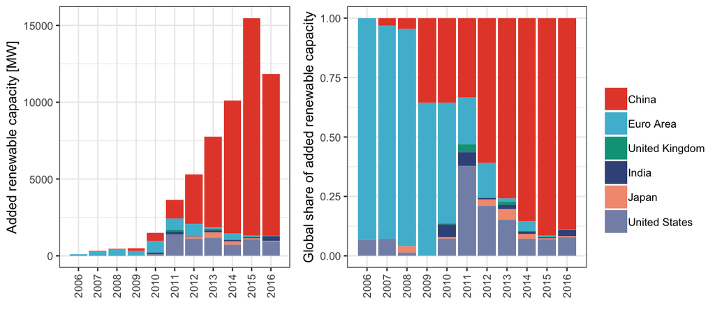

Capacity additions per year and currency area

### Step 2: Calculation of the formula variable

C are observed average cost in currency i. We use the variable average_local_costs

### Step 3: Aggregation to weighted average global costs (P)

In the third step, we aggregate the data by yearly averages for each currency. The mean is weighted by the marketshare $\delta$ (in contrast to method 1). We calculate two different $P$:

- $P$ for the unadjusted average global costs
- $P_{tilde}$ for the adjusted average global costs

### Step 4: Convert to real values

### Step 5: Calculation of the learning rate

A regression over $P_{t,2017}^l$ gives us the **un**adjusted global learning rates in USD,. The **un**adjusted rate includes both technological learning and changes in exchange rates. Therefore, it is different in different lead currencies. To get the same number in every lead currency (i.e. a truly global learning rate), we adjust the unadjusted global learning rate for the currency effect. Applying $\alpha$ to the learning rate calculation results in the adjusted global learning rate. The adjusted rate only includes technological learning. The corresponding learning curves are depicted in Figure 1.

## Method 2: Results

We get the following learning rates using the corrected learning rates approach:

```
##            2006-2011 2012-2016 2006-2016
## unadjusted     16.05     32.83     24.47
## adjusted       16.90     33.90     25.85
```

```
##            2006-2011 2012-2016 2006-2016
## unadjusted     72.71     97.83     88.52
## adjusted       81.42     92.51     89.84
```

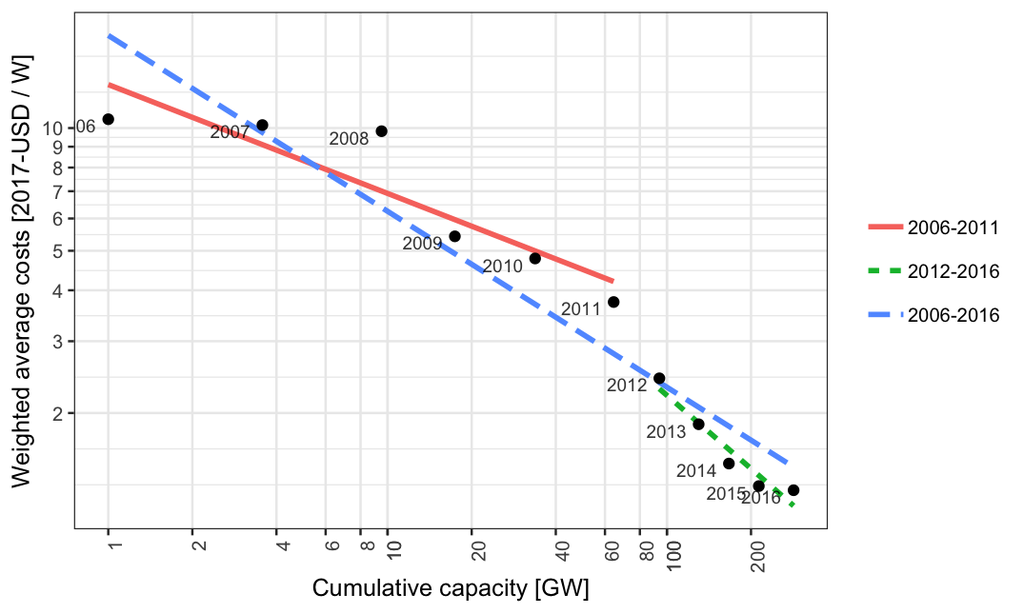

Plot of the currency-corrected learning curve in 3 intervals

### Combined plot

Plotting all learning rates in the same plot, it is necessary to norm the costs. To do this, we select one random project and devide all average global costs by that project’s value. We then get 1/W for all average costs and can compare the learning rates. The norm project is the following.

| id | date | capacity | local_currency | local_value | year | subset_name | CNY | EUR | GBP | INR | JPY | USD |
| --- | --- | --- | --- | --- | --- | --- | --- | --- | --- | --- | --- | --- |
| 26364 | 2010-06-20 | 20 | CNY | 18.5 | 2010 | BNEF with costs in interval | 18.5 | 2.05962 | 1.767724 | 124.9236 | 239.5034 | 2.732814 |

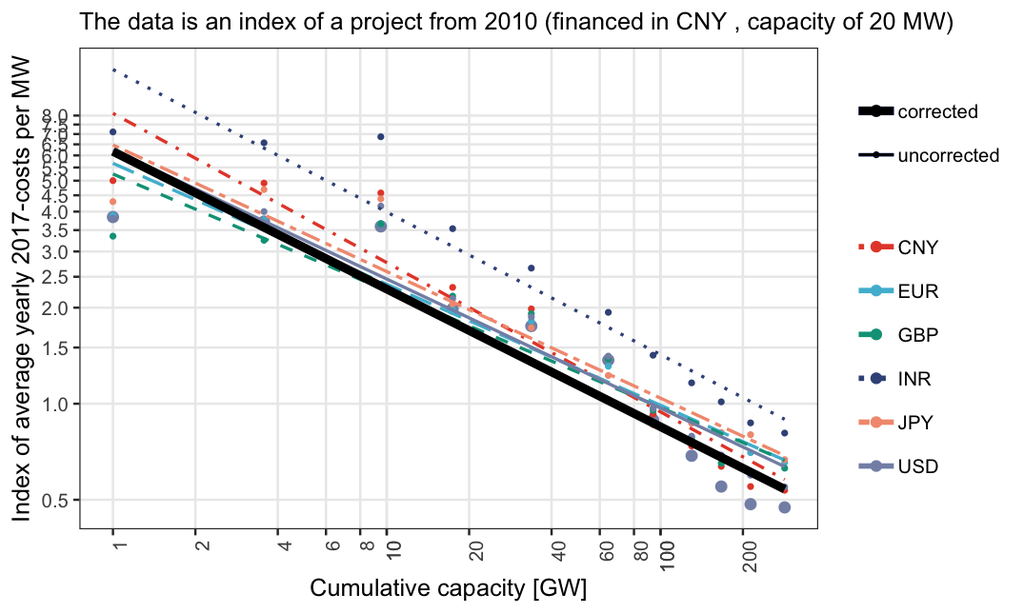

Comparison of the simple (thin lines) and currency-corrected (think line) learning rates.

# Appendix

## Linear Regression and learning rate calculation

To derive the learning curves, we applied a single-factor learning curve as defined in (Lindman and Söderholm 2012):

$ln(C_t) = \beta_0 + \beta_1 \cdot ln(CC_t).$

with, $C_t$ as the cost at time $t$, $CC_t$ as cummulative capacity at time $t$, and $\beta_0$ and $\beta_1$ as linear regression estimates. The learning rates is then derived from $\beta_1$:

$LR = 1 - 2^{\beta_1}.$

Based on these formulas, we applied a linear regression model with OLS (Ordinary Least Squares) over the transformed data (with ln-ln transformation of the predictors, as visible in the first formula).

# Literature

Lindman, Åsa, and Patrik Söderholm. 2012. “Wind power learning rates: A conceptual review and meta-analysis.” *Energy Economics* 34 (3): 754–61.